# Part II - 2019 fordgobike trip data Exploration

## by: Umar Muhammad Aminu

## Investigation Overview

> In this presentation, I plan to communicate the key insights that i derived from my exploration. The key insights are: Females bike riders appear to favour long trips(over 800secs), more bike trips happen during the evening period and the majority of the bikers are males

## Dataset Overview

> The data set includes information about individual rides made in a bike-sharing system covering the greater San Francisco Bay area. it includes information such as trip duration, start station, user gender etc. Overall, the dataset contains 16 features(columns) describing 183412 bike trips (rows)

## (Visualization 1)

> It can be seen from the plot that over 70 percent of the people that uses the bikea belong to male gender

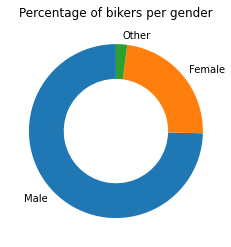

## (Visualization 2)

> It can be seen that Females appear to take long trips more. For males, Very short trip is the most popular while thier is no much difference in trip duration for people of the other gender

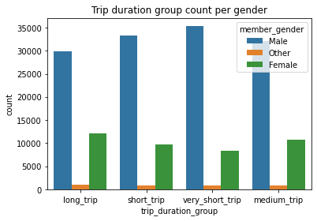

## (Visualization 3)

> It can be seen from the above plot that Evening period is the most populous period for bike trips followed by Morning and then Noon period

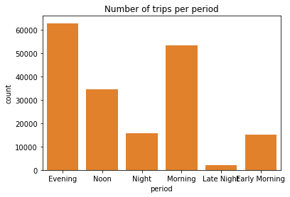